# Exercise 5 Point transect sampling

**Solutions** Point transect exercises

# Simulated data

The code for accessing and checking these data and fitting various models is shown below.

```r
library(Distance)
data("PTExercise")
head(PTExercise, n=3)
```

```
##   Region.Label Area Sample.Label Effort object distance  Study.Area
## 1      Default    0            1      1      1     8.40 PTExercise1
## 2      Default    0            2      1      2    13.79 PTExercise1
## 3      Default    0            2      1      3    20.96 PTExercise1
```

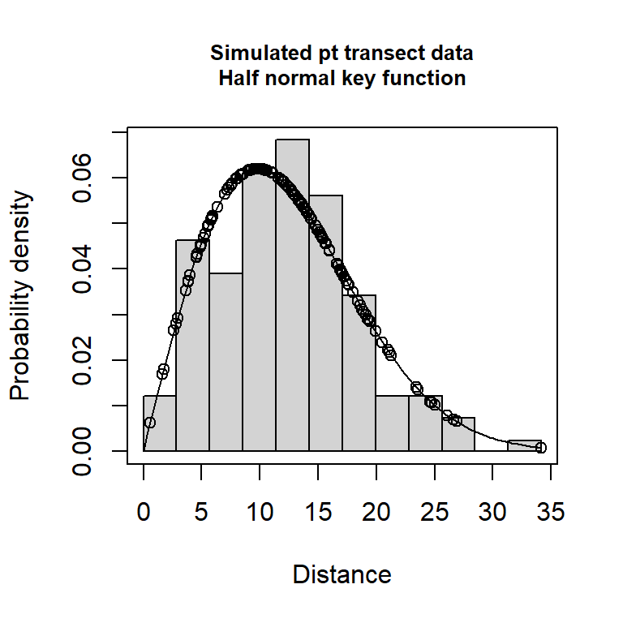

```r
conversion.factor <- convert_units("meter", NULL, "hectare")
# Fit half-normal detection function, no truncation
PTExercise.hn <- ds(data=PTExercise, transect="point", key="hn", convert_units=conversion.factor)
plot(PTExercise.hn, pdf=TRUE, main="Simulated pt transect data\nHalf normal key function")
```

## Truncation of 20m

```r
# Half normal, no adjustments
PTExercise.hn.t20m <- ds(data=PTExercise, transect="point", key="hn", truncation=20,
                    convert_units=conversion.factor)
# Hazard rate, no adjustments
PTExercise.hr.t20m <- ds(data=PTExercise, transect="point", key="hr", truncation=20,
                    convert_units=conversion.factor)
# Uniform, cosine adjustments
PTExercise.uf.cos.t20m <- ds(data=PTExercise, transect="point", key="unif",
                        adjustment="cos", truncation=20,convert_units=conversion.factor)
```

Results from simulated point transect data.

| DetectionFunction | Adjustments | Truncation | AIC | Density | D.CV | Lower.CI | Upper.CI |
| --- | --- | --- | --- | --- | --- | --- | --- |
| Half-normal | None | 34.2 | 919.140 | 79.630 | 0.126 | 62.121 | 102.074 |
| Half-normal | None | 20.0 | 764.305 | 70.826 | 0.157 | 51.978 | 96.507 |
| Hazard rate | None | 20.0 | 767.211 | 62.364 | 0.187 | 43.207 | 90.015 |
| Uniform | Cosine | 20.0 | 765.503 | 75.044 | 0.144 | 56.515 | 99.648 |

## Plots of probability density functions to inspect fit

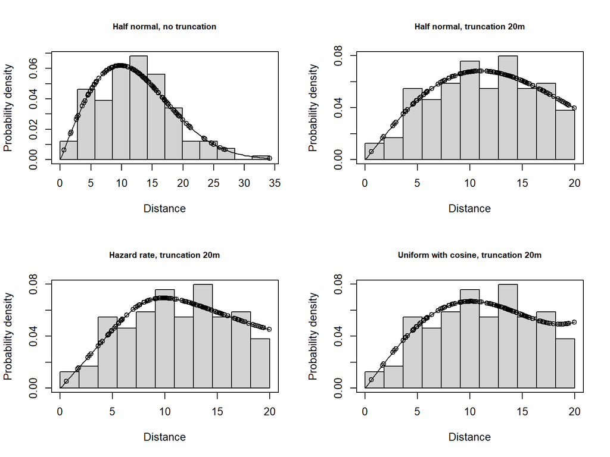

```r
par(mfrow=c(2,2))
plot(PTExercise.hn, main="Half normal, no truncation", pdf=TRUE)
plot(PTExercise.hn.t20m, main="Half normal, truncation 20m", pdf=TRUE)
plot(PTExercise.hr.t20m, main="Hazard rate, truncation 20m", pdf=TRUE)
plot(PTExercise.uf.cos.t20m, main="Uniform with cosine, truncation 20m", pdf=TRUE)
```

We see a fair degree of variability between analyses - reliable analysis of point transect data is more difficult than for line transect data. We see greater loss in precision from truncating data relative to line transect sampling, but if we do not truncate data, different models can give widely differing estimates.

# Wren data (Optional)

In the code provided below, each data set is loaded and detection functions selected in Buckland (2006) are fitted.

```r
data("wren_5min")
data("wren_snapshot")
conversion.factor <- convert_units("meter", NULL, "hectare")
wren5min.uf.cos.t110 <- ds(data=wren_5min, key="unif", adjustment="cos",
                        transect="point", truncation=110,
                        convert_units=conversion.factor)
wrensnap.hr.cos.t110 <- ds(data=wren_snapshot, key="hr", adjustment=NULL,
                        transect="point", truncation=110,
                        convert_units=conversion.factor)
```

Winter wren density estimates from 5 minute counts and snapshot moment.

| Method | Density | Lower.CI | Upper.CI |
| --- | --- | --- | --- |
| Five minute | 1.285 | 0.790 | 2.089 |
| Snapshot | 1.023 | 0.795 | 1.317 |

## Probability density functions for Buckland’s winter wren point transects

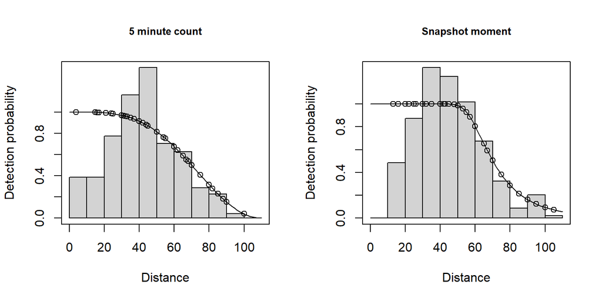

```r
# Plot detection functions
par(mfrow=c(1,2))
plot(wren5min.uf.cos.t110, main="5 minute count")
plot(wrensnap.hr.cos.t110, main="Snapshot moment")
```

As the detection distance histograms indicate, winter wren showed evidence of observer avoidance, more than other species in the Montrave study. We show the detection function graph rather than the PDF to emphasise the evasive movement aspect of the data. If you conduct the goodness of fit test, using `gof_ds()`, you will find that the models still suitably fit the data.

# References

Buckland, S. T. (2006). Point-transect surveys for songbirds: Robust methodologies. *The Auk*, *123*(2), 345–357. https://doi.org/10.1642/0004-8038(2006)123[345:PSFSRM]2.0.CO;2